# Atlas - Data Science Analysis

Author - Jordan Ukawoko & Luke Whelan

## About the Dataset - Credit Card Fraud Detection

Today, purchases through credit & debit card is the main way of making transactions for a majority of people. As we are moving more towards the digital world everyday, cybersecurity is becoming a crucial part of our life. We thought analysing a dataset focusing on credit card fraud would be interesting. In this analysis we will be focusing on cleaning the data and the classification and clustering data-mining & machine learning techniques

The dataset that we plan to use contains credit card transactions made in September 2013 by European cardholders. The transactions from this dataset are labeled as either fraudulent or non fraudulent and this will help train our machine learning models This dataset presents transactions that occurred in two days, where we have 492 frauds out of 284,807 transactions.

Each transaction consists of 31 numerical features, of which 28 are PCA-transformed ones because of confidentiality issues (V1–V28) while the others are Time (indicates the elapsed time between the first transaction in the dataset and the others, respectively), Amount (Transaction Amount) and Class (represents the output variable denoting whether fraud or not)

Link to Dataset - https://www.kaggle.com/datasets/mlg-ulb/creditcardfraud

## Part I - Data Preprocessing

Before we can use our dataset we must perform data pre-processing. Data-preprocessing is important for removing missing or inconsistent data resulting from human or computer error e.g duplicates or random data that makes no sense (noise). Data-preprocessing can help improve the accuracy and quality of our dataset and thus make it significantly more reliable and consistent.

Before we begin we will import all the necessary libraries to have them all in one place, so we can modify them quickly. This will make the task at hand easier for us to understand. For the first part of the cleaning we are dropping the time variable which can be an external deciding factor.

Time is often not as relevant for detecting fraud as other features such as transaction amount, merchant, and location. Fraudsters often attempt to cover their tracks by changing the time of a fraudulent transaction to make it appear legitimate.

We also felt that keeping time as a feature may lead to overfitting, especially if the data used for training the model contains a disproportionate number of transactions from a certain time period, like this dataset we are using.

We are also adding all of our imports to for the machine learning model. We used the pandas module to import our dataset

```python
# https://stackoverflow.com/questions/50276911/how-to-split-data-by-different-classes-in-python-3-6
# https://neptune.ai/blog/f1-score-accuracy-roc-auc-pr-auc

import numpy as np
import random
import pandas as pd
import matplotlib.pyplot as plt
from sklearn.utils import resample
from termcolor import colored as cl
from pandas import Series, DataFrame
from sklearn.metrics import f1_score
from sklearn.metrics import accuracy_score
from sklearn.metrics import confusion_matrix
from sklearn.linear_model import LogisticRegression, LinearRegression, ElasticNet, Lasso, Ridge
from sklearn.preprocessing import StandardScaler, MinMaxScaler, MaxAbsScaler
import seaborn as sns
from pylab import rcParams
import warnings
df = pd.read_csv('archive.zip') # Importing our dataset
```

We also observed in our data 28 features that are transformed versions of PCA but the amount is the original one. While observing the minimum and maximum is in the amount - we observed a huge difference that can deviate our result

```python
df.Amount.min(), df.Amount.max()
minmax = [df.min(axis = 0),df.max(axis = 0)]
minmax
```

```
[Time        0.000000
 V1        -56.407510
 V2        -72.715728
 V3        -48.325589
 V4         -5.683171
 V5       -113.743307
 V6        -26.160506
 V7        -43.557242
 V8        -73.216718
 V9        -13.434066
 V10       -24.588262
 V11        -4.797473
 V12       -18.683715
 V13        -5.791881
 V14       -19.214325
 V15        -4.498945
 V16       -14.129855
 V17       -25.162799
 V18        -9.498746
 V19        -7.213527
 V20       -54.497720
 V21       -34.830382
 V22       -10.933144
 V23       -44.807735
 V24        -2.836627
 V25       -10.295397
 V26        -2.604551
 V27       -22.565679
 V28       -15.430084
 Amount      0.000000
 Class       0.000000
 dtype: float64,
 Time      172792.000000
 V1             2.454930
 V2            22.057729
 V3             9.382558
 V4            16.875344
 V5            34.801666
 V6            73.301626
 V7           120.589494
```

[output cut: 9 more lines]

```
 V17            9.253526
 V18            5.041069
 V19            5.591971
 V20           39.420904
 V21           27.202839
 V22           10.503090
 V23           22.528412
 V24            4.584549
 V25            7.519589
 V26            3.517346
 V27           31.612198
 V28           33.847808
 Amount     25691.160000
 Class          1.000000
 dtype: float64]
```

Descriptive Statistics

```python
df.describe().T.head()
```

|  | count | mean | std | min | 25% | 50% | 75% | max |
| --- | --- | --- | --- | --- | --- | --- | --- | --- |
| Time | 284807.0 | 9.481386e+04 | 47488.145955 | 0.000000 | 54201.500000 | 84692.000000 | 139320.500000 | 172792.000000 |
| V1 | 284807.0 | 1.168375e-15 | 1.958696 | -56.407510 | -0.920373 | 0.018109 | 1.315642 | 2.454930 |
| V2 | 284807.0 | 3.416908e-16 | 1.651309 | -72.715728 | -0.598550 | 0.065486 | 0.803724 | 22.057729 |
| V3 | 284807.0 | -1.379537e-15 | 1.516255 | -48.325589 | -0.890365 | 0.179846 | 1.027196 | 9.382558 |
| V4 | 284807.0 | 2.074095e-15 | 1.415869 | -5.683171 | -0.848640 | -0.019847 | 0.743341 | 16.875344 |

```python
df.shape
```

```
(284807, 31)
```

- This tells us that the dataset at this point contains 284807 rows and 31 columns

Let us take a look at the columns

```python
df.columns
```

```
Index(['Time', 'V1', 'V2', 'V3', 'V4', 'V5', 'V6', 'V7', 'V8', 'V9', 'V10',
       'V11', 'V12', 'V13', 'V14', 'V15', 'V16', 'V17', 'V18', 'V19', 'V20',
       'V21', 'V22', 'V23', 'V24', 'V25', 'V26', 'V27', 'V28', 'Amount',
       'Class'],
      dtype='object')
```

Thus we decided to scale this variable as we thought it was good practice.

Scaling variables was important because it was done to standardise the range of values for each feature in the data, so that all features are on a similar scale. This is important because many machine learning algorithms are sensitive to the scale of the input features, and if the features are not on a similar scale, some features may dominate others, leading to biased or incorrect predictions.

We used a standard scale to make it fix. As mentioned above we dropped the time value as it can be an external deciding factor

```python
sc = StandardScaler()
amount = df['Amount'].values
df['Amount'] = sc.fit_transform(amount.reshape(-1, 1))
```

Firstly, before we move on, we will check the original amount of frauds and non frauds from our dataset. Before dropping anything or making changes the dataset already has frauds as 492 in class 1 (our negative class) and 284315 non frauds in class 0 (our positive class)

```python
df.Class.value_counts()
```

```
0    284315
1       492
Name: Class, dtype: int64
```

By looking at the above statistics, we can see that the data is highly imbalanced. Only 492 out of 284807 are fraud.

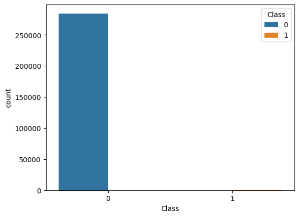

```python
sns.countplot(x=df.Class, hue=df.Class)
```

We can also check the distribution amount of the original dataset

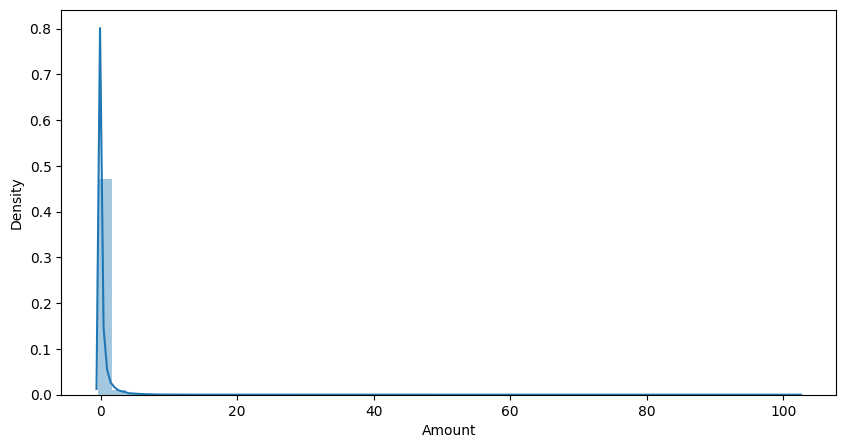

```python
plt.figure(figsize=(10, 5))
sns.distplot(df.Amount)
```

Next, will check for duplicates. Before removing any duplicate transactions found in the dataset we observed that we had a grand total of 284807 transactions. During the cleaning process we observed the changes and came to the conclusion that the dataset consisted of 283726 transactions after removing the duplicates. Removing the duplicates is important because it helps us to scale the dataset.

Removing the duplicates from this dataset was also important because duplicated data can artificially inflate the size of the dataset, leading to overfitting and a decrease in the accuracy of the model. We wanted our models to be as accurate as possible

We also felt that duplicates can lead to bias predictions. This can result in over-representation of certain classes, leading to biased predictions. For example the models may be very biased toward the non fraud class.

We have one more variable which is the time which can be an external deciding factor — but in our modelling process, we can drop it, so we decided to drop the time column during the cleaning process

```python
print(f'Number of transactions: {len(df)}')
print(f'Number of duplicates: {df.duplicated().sum()}')

df = df.drop_duplicates()
print(f'Number of transactions after dropping duplicated: {len(df)}')

df = df.drop(columns = 'Time') #Dropping time after checking duplicates
```

```
Number of transactions: 284807
Number of duplicates: 1081
Number of transactions after dropping duplicated: 283726
```

We created a box plot to investigate if there was any outliers within the dataset and our result was that the box plot showered there was quite a few outliers and we decided to drop all outliers that were outside q3 + 1.5iqr and below q1-1.5qr.

We did this again to improve the accuracy and stability of the model. Outliers can have a disproportionate impact on the model, especially if they are extreme values, and removing them can reduce the noise in the data and prevent the model from being skewed by these values.

These are the results we got.

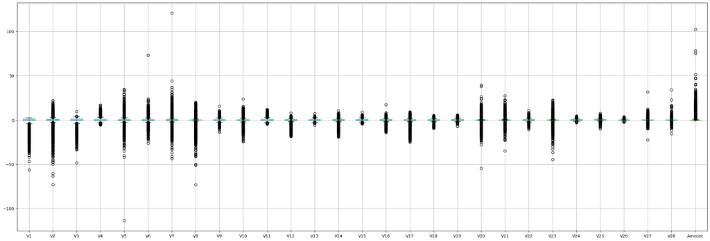

```python
%matplotlib inline
data2 = df.drop(['Class'],axis=1)
data2['V1'] = pd.to_numeric(data2['V1'])
data2.boxplot(figsize=(30,10))
```

We can see that there exists alot of outlier. We decided to calculate Q1 and Q3 using the whole data set, but only drop outliers in the 0 class. If we dropped outliers in class 1, the data will only contain 17 frauds out of 146000 transactions.

```python
# Deletes outliers, only in class 0, otherwise to many points of the minority class would be droped
by_class = df.groupby('Class')
tmp_0 = pd.DataFrame(by_class.get_group(0))
tmp_1 = pd.DataFrame(by_class.get_group(1))
for x in df.columns[0:-1]:
    q75,q25 = np.percentile(df.loc[:,x],[75,25])
    intr_qr = q75-q25

    max = q75+(1.5*intr_qr)
    min = q25-(1.5*intr_qr)

    tmp_0.loc[tmp_0[x] < min,x] = np.nan
    tmp_0.loc[tmp_0[x] > max,x] = np.nan
    a = len(df)
    df = pd.concat([tmp_0.iloc[:], tmp_1.iloc[:]])
    b = len(df)
    n_downsampled = a-b
df = df.dropna()
check_for_0 = df.drop(['Class'],axis=1)
n_datapoints = len(df)
print(f'Are there any 0 values in the data? {0 in check_for_0}')
print(f'New number of transactions: {n_datapoints}')
```

```
Are there any 0 values in the data? False
New number of transactions: 146411
```

Thus we know there are no null values in this dataset

We took a new look at the box plot and observed the values were a lot lower. As we got a new q1 and q3 we can see that there is still some outliers within the dataset but these are assumed to be part of class 1 and since we deleted outlier from class zero as we had too many too data-points, remove outliers and balanced the dataset. The new dataset contains only half of the original data points.

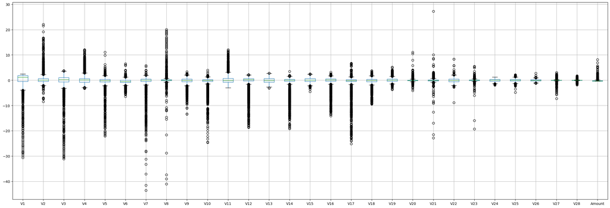

```python
%matplotlib inline
data2 = df.drop(['Class'],axis=1)
data2['V1'] = pd.to_numeric(data2['V1'])
data2.boxplot(figsize=(30,10))
```

```python
minmax = [df.min(axis = 0),df.max(axis = 0)]
minmax
```

```
[V1       -30.552380
 V2        -8.402154
 V3       -31.103685
 V4        -3.234792
 V5       -22.105532
 V6        -6.406267
 V7       -43.557242
 V8       -41.044261
 V9       -13.434066
 V10      -24.588262
 V11       -2.988333
 V12      -18.683715
 V13       -3.127795
 V14      -19.214325
 V15       -4.498945
 V16      -14.129855
 V17      -25.162799
 V18       -9.498746
 V19       -3.681904
 V20       -4.128186
 V21      -22.797604
 V22       -8.887017
 V23      -19.254328
 V24       -2.028024
 V25       -4.781606
 V26       -1.176759
 V27       -7.263482
 V28       -1.869290
 Amount    -0.353229
 Class      0.000000
 dtype: float64,
 V1         2.454930
 V2        22.057729
 V3         3.790995
 V4        12.114672
 V5        11.095089
 V6         6.474115
 V7         5.802537
 V8        20.007208
 V9         3.353525
 V10        4.031435
 V11       12.018913
 V12        2.151044
 V13        2.815440
 V14        3.442422
 V15        2.497402
 V16        3.139656
 V17        6.739384
 V18        3.790316
 V19        5.228342
 V20       11.059004
 V21       27.202839
 V22        8.361985
 V23        5.466230
 V24        1.299212
 V25        2.208209
 V26        2.745261
 V27        3.052358
 V28        1.779364
 Amount     8.146182
 Class      1.000000
 dtype: float64]
```

We decided to handle the remaining data in two different ways, creating two new data sets which we are comparing the clustering and classification results for. Only one of the sampling strategy should be run!

# Only one of the sampling strategy should be run!

### First data set

Before splitting train & test — we needed to define dependent and independent variables. The dependent variable is also known as X and the independent variable is known as y.

The first step we did was to split the original dataset into two subsets, with a portion for training. We split it by 80% for training and 20% for testing

We trained the different models using the training data. This involves feeding the training data into the model, allowing the model to learn from the data.

```python
# 1 way of handeling the data.
# Upsampling the minority class, downsampling the majority class, splitting the data. Still unbalanced data
# The minority class is being upsampled after splitting the data, which means that the test set contains
# data thats never been seen before
def split_dataset(df, split_size=0.8, downsample = True, frac_downsample = 0.2, upsample = True, frac_upsample = 0.5):

    n_downsampled = 0
    n_upsampled = 0
    df_train = pd.DataFrame()
    df_test = pd.DataFrame()
    by_class = df.groupby('Class')

    if downsample:
        # Deletes % of the majority class
        a = len(df)
        df = df.drop(df[df['Class'] == 0].sample(frac=frac_downsample).index)
        b = len(df)
        n_downsampled = a-b


    sampled_df = df
    c = int(0.8*len(by_class.get_group(0)))
    df_train = df_train.append(by_class.get_group(0).iloc[0:c])
    df_test = df_test.append(by_class.get_group(0).iloc[c:])
    c = int(0.8*len(by_class.get_group(1)))
    df_train = df_train.append(by_class.get_group(1).iloc[0:c])
    df_test = df_test.append(by_class.get_group(1).iloc[c:])

    by_class2 = df_train.groupby('Class')
    if upsample:
        #upsampling the minority class with given%
        df_minority = resample(by_class2.get_group(1), replace=True, n_samples=int(len(by_class2.get_group(1))*frac_upsample))
        df_train = pd.concat([df_train, df_minority])
        n_upsampled = len(df_minority)




    return df_train, df_test, sampled_df, n_upsampled, n_downsampled

df_train, df_test, sampled_df, n_upsampled, n_downsampled = split_dataset(df, downsample = True, frac_downsample = 0.5, upsample = True, frac_upsample = 5 )
```

```python
Total_transactions = len(df)
normal = len(df[df.Class == 0])
fraudulent = len(df[df.Class == 1])
fraud_percentage = round(fraudulent/normal*100, 2)
fraud_percentage2 = round((fraudulent+n_upsampled)/normal*100,2)
print(cl('Total number of Transactions without sampling are {}'.format(Total_transactions), attrs = ['bold']))
print(cl('Number of Normal Transactions without sampling are {}'.format(normal), attrs = ['bold']))
print(cl('Number of fraudulent Transactions without sampling are {}'.format(fraudulent), attrs = ['bold']))
print(cl('Percentage of fraudulent Transactions without sampling is {}'.format(fraud_percentage), attrs = ['bold']))
print(cl('Number of transactions downsampled {}'.format(n_downsampled), attrs = ['bold']))
print(cl('Number of frauds transactions upsampled {}'.format(n_upsampled), attrs = ['bold']))
print(cl('Percentage of fraudulent Transactions after upsampling is {}'.format(fraud_percentage2), attrs = ['bold']))
```

```
Total number of Transactions without sampling are 146411
Number of Normal Transactions without sampling are 78520
Number of fraudulent Transactions without sampling are 67891
Percentage of fraudulent Transactions without sampling is 86.46
Number of transactions downsampled 39260
Number of frauds transactions upsampled 271560
Percentage of fraudulent Transactions after upsampling is 432.31
```

### Second data set - SMOTE Function

In this sampling strategy, the function SMOTE from imblearn is being used. It creates synthetical data points for the minority class that reminds of allready existing points. The data will be balanced, but the synthetical data points might be one to many.

In general smote was used as an oversampling method to balance the class distribution since the dataset was highly imbalanced. The goal of using smote as mentioned above is to generate synthetic samples of the minority class in order to balance the dataset and improve the distribution and performance of he model.

How smote was performed in our analysis was that it identified the minority class which was the fraud and calculated its class distribution. The class distribution was 0.32%

For each sample in the minority class, SMOTE calculates the k-nearest neighbors based on the Euclidean distance between the sample and its neighbors.

For each sample in the minority class, SMOTE generates synthetic samples by randomly selecting one of its k-nearest neighbors and calculating the difference between the selected neighbor and the sample. The synthetic sample is generated by adding this difference to the sample.

The original samples and the synthetic samples are combined to create a new, balanced dataset.

Finally we trained the machine learning model on the balanced dataset

```python
!pip install imblearn==0.0
```

```python
#!pip install imblearn
# second strategy for handeling the data set.
from imblearn.over_sampling import SMOTE
# resample data with the function SMOTE. makes the data balanced.
def smoot(df,frac_downsample = 0.5, downsample = False):

    df_train = pd.DataFrame()
    df_test = pd.DataFrame()
    by_class = df.groupby('Class')
    if downsample:
        df = df.drop(df[df['Class'] == 0].sample(frac=frac_downsample).index) #downsamples

    frauds = len(df[df.Class == 1])
    df[df.columns[0:-1]],df[df.columns[-1]] = SMOTE().fit_resample(df[df.columns[0:-1]],df[df.columns[-1]])
    b = len(df[df.Class == 1])
    n_upsampled = b-frauds

    c = int(0.8*len(by_class.get_group(0)))
    df_train = df_train.append(by_class.get_group(0).iloc[0:c])
    df_test = df_test.append(by_class.get_group(0).iloc[c:])
    c = int(0.8*len(by_class.get_group(1)))
    df_train = df_train.append(by_class.get_group(1).iloc[0:c])
    df_test = df_test.append(by_class.get_group(1).iloc[c:])

    return df_train, df_test, df, n_upsampled, frauds

df_train, df_test, df, n_upsampled, frauds = smoot(df,frac_downsample = 0.5, downsample = False)
```

```python
Total_transactions = len(df)
normal = len(df[df.Class == 0])
fraudulent = len(df[df.Class == 1])
fraud_percentage = round(fraudulent/Total_transactions*100, 2)
fraud_percentage2 = round((fraudulent+n_upsampled)/normal*100,2)
print(cl('Total number of Transactions without sampling are {}'.format(Total_transactions), attrs = ['bold']))
print(cl('Number of Normal Transactions without sampling are {}'.format(n_datapoints-frauds), attrs = ['bold']))
print(cl('Number of fraudulent Transactions without SMOTE are {}'.format(frauds), attrs = ['bold']))
print(cl('Percentage of fraudulent Transactions with SMOTE is {}'.format(fraud_percentage), attrs = ['bold']))
print(cl('Number of frauds transactions upsampled {}'.format(n_upsampled), attrs = ['bold']))
print(cl('Percentage of fraudulent Transactions after upsampling is {}'.format(fraud_percentage2), attrs = ['bold']))
```

```
Total number of Transactions without sampling are 146411
Number of Normal Transactions without sampling are 145919
Number of fraudulent Transactions without SMOTE are 492
Percentage of fraudulent Transactions with SMOTE is 0.32
Number of frauds transactions upsampled 1890
Percentage of fraudulent Transactions after upsampling is 1.62
```

Let's showcase all the different columns in different histograms

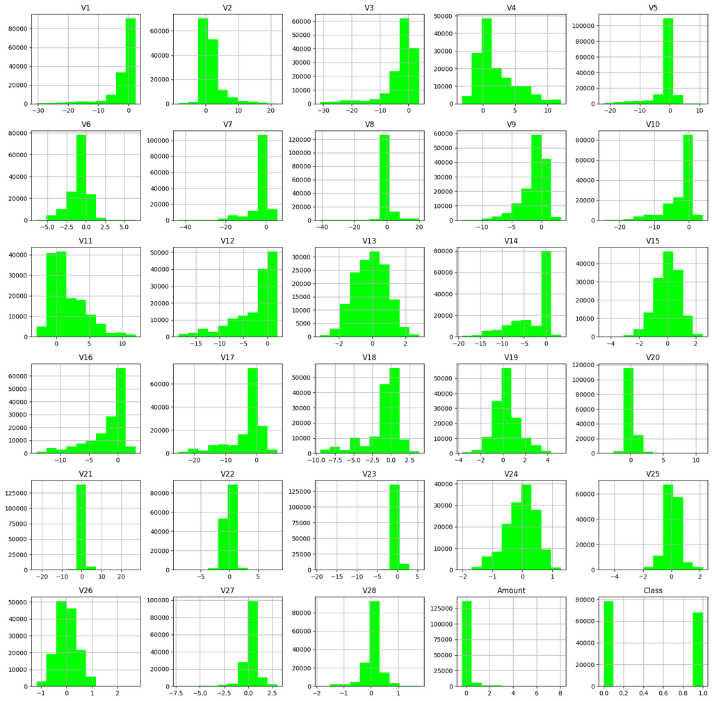

```python
df.hist(figsize=(20,20),color='lime')
plt.show()
```

This shows the correlation between fraud and non fraudulent

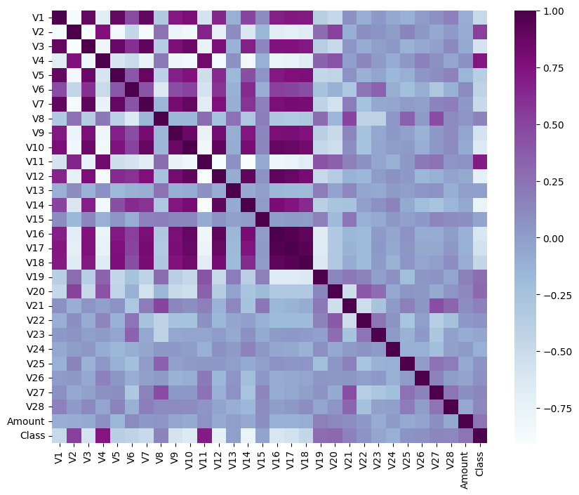

```python
plt.figure(figsize=(10,8))
corr=df.corr()
sns.heatmap(corr,cmap='BuPu')
```

### Part II - Classification

Model 1 - Decision Trees

We decided for the second part of this analysis that we would focus on classification. We built different machine learning models one by one.These classifier models will be using the data we upsampled and downsampled. The five model we focused on were Decision Trees, Logistic Regression, Random Forest, XGBoost and K-Nearest Neighbours. We compared the five different machine learning classification models to each other and found the model with the strongest f1 score, accuracy, precision and recall.

```python
# Our Classifier
from sklearn.neighbors import KNeighborsClassifier
from sklearn.tree import DecisionTreeClassifier
from sklearn.linear_model import LogisticRegression, LinearRegression, ElasticNet, Lasso, Ridge
from sklearn.ensemble import BaggingClassifier, BaggingRegressor,RandomForestClassifier,RandomForestRegressor
from sklearn.metrics import confusion_matrix
from sklearn.ensemble import GradientBoostingClassifier,GradientBoostingRegressor, AdaBoostClassifier, AdaBoostRegressor
from sklearn.svm import LinearSVC, LinearSVR, SVC, SVR
from xgboost import XGBClassifier



#Metrics for classification
from sklearn.metrics import precision_recall_curve
from sklearn.model_selection import cross_val_score
from sklearn.metrics import accuracy_score
from sklearn.metrics import f1_score
from sklearn.metrics import precision_score
from sklearn.metrics import recall_score
from sklearn.metrics import average_precision_score
```

The first machine learning model we decided to implement was decision tree. A decision tree is one of the supervised machine learning algorithms. This algorithm can be used for regression and classification problems — yet, is mostly used for classification problems. We calculated the f1 score, accuracy, precision and recall for the decision tree and we created a graph to compare the accuracy to the precision to the recall.

```
Accuracy for DT-classifier: 0.999726803947683
Precision for DT-classifier: 0.9263157894736842
Recall for DT-classifier: 0.9887640449438202
F1-score for DT-classifier: 0.9565217391304348
0.9161467934411056
```

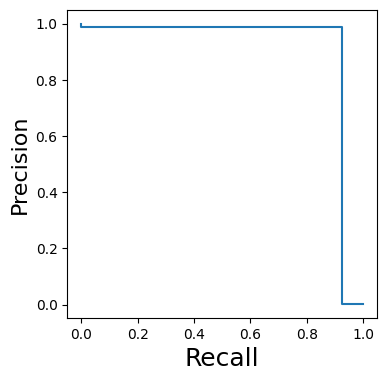

```python
# Decision Tree
DT = DecisionTreeClassifier(random_state=0)
DT.fit(df_train[df_train.columns[0:-1]],df_train[df_train.columns[-1]])
pred = DT.predict(df_test[df_test.columns[0:-1]])
#CrossValidation
#for score in ['accuracy', 'roc_auc']:
#    s = cross_val_score(DT, df[df.columns[0:-1]],df[df.columns[-1]], scoring = score, cv=2)
#    print(f'Model {score}, Mean = {s.mean()}, standard dev = {s.std()}')

y_score = DT.predict_proba(df_test[df_test.columns[0:-1]])[:,1]

precision, recall, _ = precision_recall_curve(df_test[df_test.columns[-1]],y_score)
auprc = average_precision_score(df_test[df_test.columns[-1]], y_score)

print(f'Accuracy for DT-classifier: {accuracy_score(pred,df_test[df_test.columns[-1]])}')
print(f'Precision for DT-classifier: {precision_score(pred,df_test[df_test.columns[-1]])}')
print(f'Recall for DT-classifier: {recall_score(pred,df_test[df_test.columns[-1]])}')
print(f'F1-score for DT-classifier: {f1_score(pred,df_test[df_test.columns[-1]])}')
print(auprc)

plt.figure(figsize=(4,4))
plt.step(recall, precision, where='post')
plt.xlabel('Recall', fontsize=18)
plt.ylabel('Precision', fontsize=16)
plt.show()
```

We also checked the confusion matrix for the decision tree model. Here, the first row represents positive and the second row represents negative.

Confusion Matrix -> True Positive, False Positive, False Negative, True Negative

```python
confusion_matrix(df_test[df_test.columns[-1]], pred, labels = [0, 1])
```

```
array([[29187,     1],
       [    7,    88]])
```

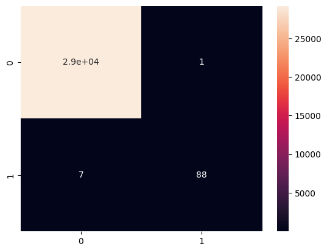

```python
import seaborn as sns
sns.heatmap(confusion_matrix(df_test[df_test.columns[-1]], pred, labels = [0, 1])
, annot=True)
```

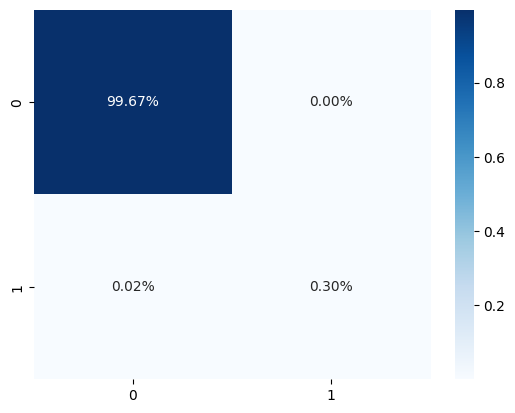

```python
sns.heatmap(confusion_matrix(df_test[df_test.columns[-1]], pred, labels = [0, 1])/np.sum(confusion_matrix(df_test[df_test.columns[-1]], pred, labels = [0, 1])), annot=True,
            fmt='.2%', cmap='Blues')
```

Model 2 - K Nearest Neighbours

Secondly we decided to implement the k nearest neighbour classifier. The k-nearest neighbors algorithm, also known as KNN or k-NN, is a non-parametric, supervised learning classifier, which uses proximity to make classifications or predictions about the grouping of an individual data point. We calculated the f1 score, accuracy, precision and recall for the k nearest neighbour and we created a graph to compare the accuracy to the precision to the recall.

```
Accuracy for KNN-classifier: 0.9995560564149848
Precision for KNN-classifier: 0.8736842105263158
Recall for KNN-classifier: 0.9880952380952381
F1-score for KNN-classifier: 0.9273743016759777
0.8635691986139106
```

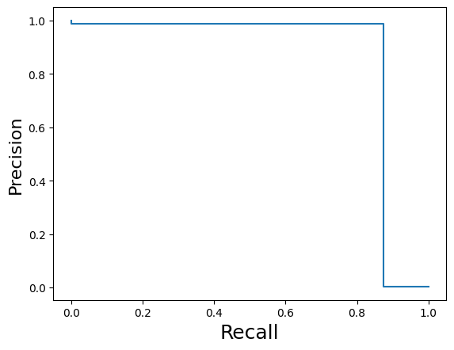

```python
# KNN
knn = KNeighborsClassifier(5)
knn.fit(df_train[df_train.columns[0:-1]],df_train[df_train.columns[-1]])
pred = knn.predict(df_test[df_test.columns[0:-1]])
y_score = knn.predict_proba(df_test[df_test.columns[0:-1]])[:,1]

precision, recall, _ = precision_recall_curve(df_test[df_test.columns[-1]],y_score)
auprc = average_precision_score(df_test[df_test.columns[-1]], y_score)

print(f'Accuracy for KNN-classifier: {accuracy_score(pred,df_test[df_test.columns[-1]])}')
print(f'Precision for KNN-classifier: {precision_score(pred,df_test[df_test.columns[-1]])}')
print(f'Recall for KNN-classifier: {recall_score(pred,df_test[df_test.columns[-1]])}')
print(f'F1-score for KNN-classifier: {f1_score(pred,df_test[df_test.columns[-1]])}')
print(auprc)
plt.step(recall, precision, where='post')
plt.xlabel('Recall', fontsize=18)
plt.ylabel('Precision', fontsize=16)
plt.figure(figsize=(4,4))
plt.show()
```

```python
confusion_matrix(df_test[df_test.columns[-1]], pred, labels = [0, 1])
```

```
array([[29187,     1],
       [   12,    83]])
```

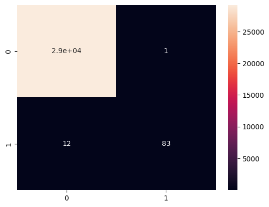

```python
import seaborn as sns
sns.heatmap(confusion_matrix(df_test[df_test.columns[-1]], pred, labels = [0, 1])
, annot=True)
```

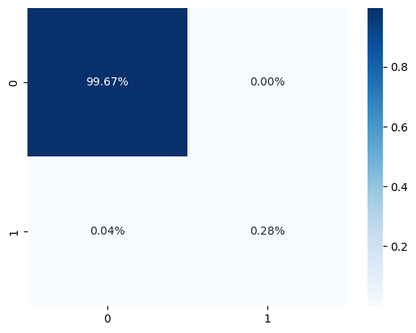

```python
sns.heatmap(confusion_matrix(df_test[df_test.columns[-1]], pred, labels = [0, 1])/np.sum(confusion_matrix(df_test[df_test.columns[-1]], pred, labels = [0, 1])), annot=True,
            fmt='.2%', cmap='Blues')
```

We also checked the confusion matrix for the KNN model. Here, the first row represents positive and the second row represents negative.We felt the decision tree and KNN had trouble rouble with particular datapoints.

Model 3 - Logistic Regression

Next we decided to implement the logistic regression classifier. Logistic regression is an example of supervised learning. It is used to calculate or predict the probability of a binary (yes/no) event occurring. We calculated the f1 score, accuracy, precision and recall for the logistic regression and we created a graph to compare the accuracy to the precision to the recall.

```
Accuracy for LR-classifier: 0.9996585049346037
Precision for LR-classifier: 0.8947368421052632
Recall for LR-classifier: 1.0
F1-score for LR-classifier: 0.9444444444444444
0.9141990559449593
```

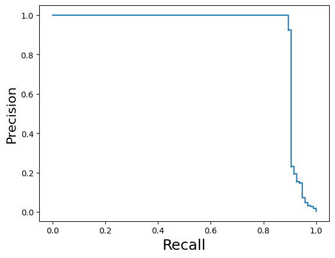

```python
# Logistic Regression
lr = LogisticRegression()
lr.fit(df_train[df_train.columns[0:-1]],df_train[df_train.columns[-1]])
pred = lr.predict(df_test[df_test.columns[0:-1]])
y_score = lr.predict_proba(df_test[df_test.columns[0:-1]])[:,1]

precision, recall, _ = precision_recall_curve(df_test[df_test.columns[-1]],y_score)
auprc = average_precision_score(df_test[df_test.columns[-1]], y_score)

print(f'Accuracy for LR-classifier: {accuracy_score(pred,df_test[df_test.columns[-1]])}')
print(f'Precision for LR-classifier: {precision_score(pred,df_test[df_test.columns[-1]])}')
print(f'Recall for LR-classifier: {recall_score(pred,df_test[df_test.columns[-1]])}')
print(f'F1-score for LR-classifier: {f1_score(pred,df_test[df_test.columns[-1]])}')
print(auprc)
plt.step(recall, precision, where='post')
plt.xlabel('Recall', fontsize=18)
plt.ylabel('Precision', fontsize=16)
plt.figure(figsize=(4,4))
plt.show()
```

```python
confusion_matrix(df_test[df_test.columns[-1]], pred, labels = [0, 1])
```

```
array([[29188,     0],
       [   10,    85]])
```

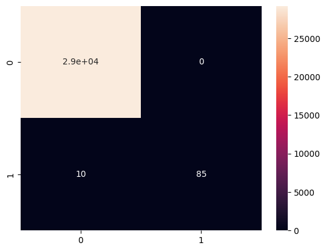

```python
import seaborn as sns
sns.heatmap(confusion_matrix(df_test[df_test.columns[-1]], pred, labels = [0, 1])
, annot=True)
```

```python
sns.heatmap(confusion_matrix(df_test[df_test.columns[-1]], pred, labels = [0, 1])/np.sum(confusion_matrix(df_test[df_test.columns[-1]], pred, labels = [0, 1])), annot=True,
            fmt='.2%', cmap='Blues')
```

[output not shown]

We checked the confusion matrix for the Logistic Regression model.

Model 4 - Random Forest

Next we decided to implement the Random Forest classifier. Random forests or random decision forests is an ensemble learning method for classification, regression and other tasks that operates by constructing a multitude of decision trees at training time. We calculated the accuracy, precision, recall and f-1 score for the random forest classifier.

```
Accuracy for rf-classifier: 0.9996926544411433
Precision for rf-classifier: 0.9052631578947369
Recall for rf-classifier: 1.0
F1-score for rf-classifier: 0.9502762430939227
0.9370477748891819
```

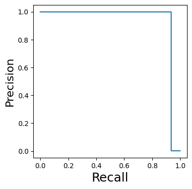

```python
# Random Forest
rf = RandomForestClassifier(max_depth = 4)
rf.fit(df_train[df_train.columns[0:-1]],df_train[df_train.columns[-1]])
pred = rf.predict(df_test[df_test.columns[0:-1]])
#CrossValidation
#for score in ['accuracy', 'roc_auc']:
#    s = cross_val_score(rf, df[df.columns[0:-1]],df[df.columns[-1]], scoring = score, cv=2)
#    print(f'Model {score}, Mean = {s.mean()}, standard dev = {s.std()}')

y_score = rf.predict_proba(df_test[df_test.columns[0:-1]])[:,1]

precision, recall, _ = precision_recall_curve(df_test[df_test.columns[-1]],y_score)
auprc = average_precision_score(df_test[df_test.columns[-1]], y_score)

print(f'Accuracy for rf-classifier: {accuracy_score(pred,df_test[df_test.columns[-1]])}')
print(f'Precision for rf-classifier: {precision_score(pred,df_test[df_test.columns[-1]])}')
print(f'Recall for rf-classifier: {recall_score(pred,df_test[df_test.columns[-1]])}')
print(f'F1-score for rf-classifier: {f1_score(pred,df_test[df_test.columns[-1]])}')
print(auprc)

plt.figure(figsize=(4,4))
plt.step(recall, precision, where='post')
plt.xlabel('Recall', fontsize=18)
plt.ylabel('Precision', fontsize=16)
plt.show()
```

```python
confusion_matrix(df_test[df_test.columns[-1]], pred, labels = [0, 1])
```

```
array([[29188,     0],
       [    9,    86]])
```

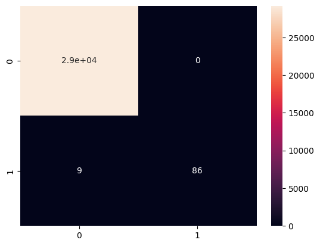

```python
import seaborn as sns
sns.heatmap(confusion_matrix(df_test[df_test.columns[-1]], pred, labels = [0, 1])
, annot=True)
```

```python
sns.heatmap(confusion_matrix(df_test[df_test.columns[-1]], pred, labels = [0, 1])/np.sum(confusion_matrix(df_test[df_test.columns[-1]], pred, labels = [0, 1])), annot=True,
            fmt='.2%', cmap='Blues')
```

[output not shown]

We also checked the confusion matrix for he random forest classifier.

Model 5 - XGBoost

Finally we had the XGBoost Model, XGBoost, which stands for Extreme Gradient Boosting, is a scalable, distributed gradient-boosted decision tree (GBDT) machine learning library. It provides parallel tree boosting and is the leading machine learning library for regression, classification, and ranking problems.It’s vital to an understanding of XGBoost to first grasp the machine learning concepts and algorithms that XGBoost builds upon: supervised machine learning, decision trees, ensemble learning, and gradient boosting.

We calculated the accuracy, precision, recall and f-1 score for the XGBoost Classifier

```
Accuracy for XGB-classifier: 0.9996926544411433
Precision for XGB-classifier: 0.9052631578947369
Recall for XGB-classifier: 1.0
F1-score for XGB-classifier: 0.9502762430939227
0.9484943181198505
```

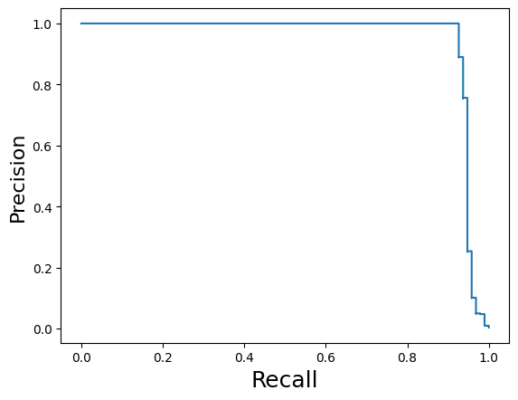

```python
# XGBBoost
xgb = XGBClassifier(max_depth = 4)
xgb.fit(df_train[df_train.columns[0:-1]],df_train[df_train.columns[-1]])
pred = xgb.predict(df_test[df_test.columns[0:-1]])
y_score = xgb.predict_proba(df_test[df_test.columns[0:-1]])[:,1]

precision, recall, _ = precision_recall_curve(df_test[df_test.columns[-1]],y_score)
auprc = average_precision_score(df_test[df_test.columns[-1]], y_score)

print(f'Accuracy for XGB-classifier: {accuracy_score(pred,df_test[df_test.columns[-1]])}')
print(f'Precision for XGB-classifier: {precision_score(pred,df_test[df_test.columns[-1]])}')
print(f'Recall for XGB-classifier: {recall_score(pred,df_test[df_test.columns[-1]])}')
print(f'F1-score for XGB-classifier: {f1_score(pred,df_test[df_test.columns[-1]])}')
print(auprc)
plt.step(recall, precision, where='post')
plt.xlabel('Recall', fontsize=18)
plt.ylabel('Precision', fontsize=16)
plt.figure(figsize=(4,4))
plt.show()
```

We also calculated the confusion matrix of the XGBoost Model

```python
confusion_matrix(df_test[df_test.columns[-1]], pred, labels = [0, 1])
```

```
array([[29188,     0],
       [    9,    86]])
```

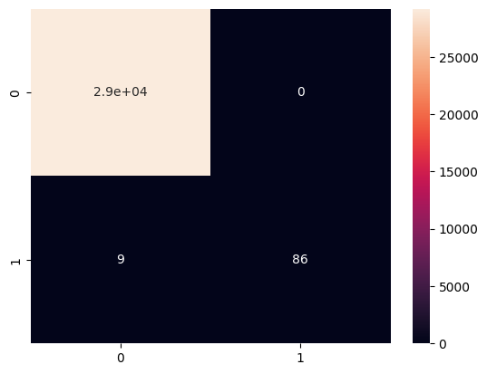

```python
import seaborn as sns
sns.heatmap(confusion_matrix(df_test[df_test.columns[-1]], pred, labels = [0, 1])
, annot=True)
```

```python
sns.heatmap(confusion_matrix(df_test[df_test.columns[-1]], pred, labels = [0, 1])/np.sum(confusion_matrix(df_test[df_test.columns[-1]], pred, labels = [0, 1])), annot=True,
            fmt='.2%', cmap='Blues')
```

[output not shown]

Best Model?

For choosing the best model we looked at different evaluation metrics to compare between the different models. We compared the accuracy, recall and precision for each model Recall and Precision were important comparisons because false negatives or false positives could be harmful.

Other reasons why XGBoost was the best model for us is that, XGBoost is known for its high accuracy, especially for problems where the relationship between features and target variables is complex. This is often the case with credit card fraud detection, where there may be many factors that contribute to a transaction being fraudulent or not.

Another huge plus was that we found the XGBoost trains models a lot faster compared to there models, even a large dataset like this one. We need to detect fraud quick similar to real world situations.

This dataset was also incredibly imbalanced. XGBoost is robust to imbalanced dataset and was able to handle the dataset effectively

## Datamining Techniques - Clustering

```python
#Clustering
from sklearn.cluster import KMeans
from sklearn.cluster import DBSCAN
from sklearn.metrics import silhouette_score
from sklearn.metrics import calinski_harabasz_score
```

```
1
2
3
4
5
6
```

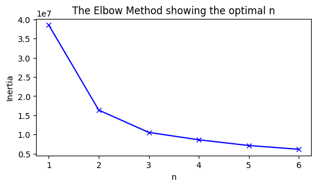

```
[0.6707844530291338, 0.5315271203462162, 0.5275893705803756, 0.5408767030707083, 0.49861110275275394]
[198671.81548390596, 194502.21387677497, 169658.62104065323, 161496.49400741147, 154433.45585088973]
```

```python
N = range(1,7)
dist = []
inert = []
sil_score = []
CH_score = []
data = df.drop(['Class'],axis=1)
for n in N:
    kmeans = KMeans(n_clusters=n, random_state=0).fit(data)
    inert.append(kmeans.inertia_)
    labels = kmeans.labels_
    if n > 1:
        y_hat = kmeans.predict(data)
        CH_score.append(calinski_harabasz_score(data, labels))
        sil_score.append(silhouette_score(data, labels, metric = 'euclidean'))
    print(n) #printing just to see that it runs

plt.figure(figsize=(6,3))
plt.plot(N, inert, 'bx-')
plt.xlabel('n')
plt.ylabel('Inertia')
plt.title('The Elbow Method showing the optimal n')
plt.show()
print(sil_score)
print(CH_score)
```

From the elbow method, its hard to see which number of clusters should be optimal for K-Means for the unbalanced data set. For the balanced data, it is clear from the elbow-plot that n = 2 is the best choice. Looking at the silhouette score as well as the Calinski-Harabasz index, we can see that a cluster size of 2 gives the highest scores. We decided to plot the clusters for n = 2 and compare it to the ground truth.

The Elbow method works by computing the WCSS for different number of clusters, with the WCSS calculated for a range of the number of clusters.

We plotted the WCSS against different number of clusters, as seen in the graph above. We felt the elbow method was useful because it provides a simple and intuitive way to determine the optimal number of clusters in a clustering algorithm

```
<bound method Figure.show of <Figure size 640x480 with 1 Axes>>
```

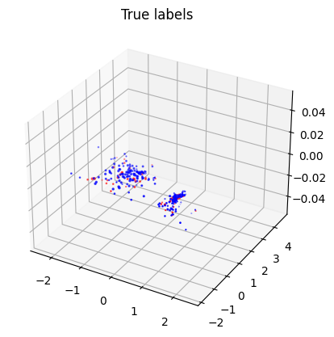

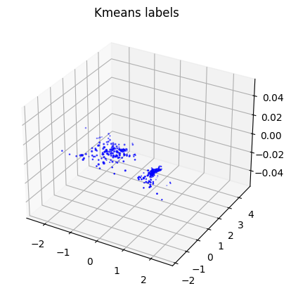

```python
# KMeans with n_clusters = 2, since that was what we got from the silhouette and CH scores
PCAs = [0,1,2]

data = df.drop(['Class'],axis=1)
kmeans = KMeans(n_clusters=2, random_state=0).fit(data)
class0 = np.where(kmeans.labels_ == 0)
class1 = np.where(kmeans.labels_ == 1)

df_array = np.array(df)
true_class_0 = np.where(df_array[:,-1] == 0)
true_class_1 = np.where(df_array[:,-1] == 1)

sample0 = np.random.choice(len(np.array(true_class_0[0])),400)
sample1 = np.random.choice(len(np.array(true_class_1[0])),100)

samples = []
for i in range(len(sample0)):
    samples.append(sample0[i])
for i in range(len(sample1)):
    samples.append(sample1[i])

class0 = []
class1 = []
for i in range(len(samples)):
    if kmeans.labels_[samples[i]] == 0:
        class0.append(samples[i])
    else:
        class1.append(samples[i])


fig1 = plt.figure(1)
ax = fig1.add_subplot(projection='3d')
plt.title('True labels')
plt.scatter(df_array[sample0,PCAs[0]],df_array[sample0,PCAs[1]],df_array[sample0,PCAs[2]], color = 'blue')
plt.scatter(df_array[sample1,PCAs[0]],df_array[sample1,PCAs[1]],df_array[sample1,PCAs[2]], color = 'red')
fig1.show

fig2 = plt.figure(2)
ax = fig2.add_subplot(projection='3d')
plt.title('Kmeans labels')
plt.scatter(df_array[class0,PCAs[0]],df_array[class0,PCAs[1]],df_array[class0,PCAs[2]], color = 'blue')
plt.scatter(df_array[class1,PCAs[0]],df_array[class1,PCAs[1]],df_array[class1,PCAs[2]], color = 'red')
fig2.show
```

```python
#DBSCAN
epsi = [0.2, 0.4, 0.6, 0.8, 1]
num_classes = []
CH_scores = []
sil_scores = []
n_outliers = []
all_labels = []
for eps in epsi:

    clustering = DBSCAN(eps=eps, min_samples=100).fit(df)
    labels = clustering.labels_
    n_outliers.append(sum(labels == -1))
    num_classes.append(labels.max()+1)
    all_labels.append(labels)
    print(eps)

    CH_scores.append(calinski_harabasz_score(df, labels))
    sil_scores.append(silhouette_score(df, labels, metric = 'euclidean'))

print(CH_scores)
print(sil_scores)
print(num_classes)
```

```
0.2
0.4
0.6
0.8
1
[55.290844934737535, 1689.3477416640424, 1102.1142696715824, 808.7545749270598, 770.7693837701238]
[0.047566457666743535, -0.5556277073732795, -0.5579206411271067, -0.4924452658294027, -0.39416321185820885]
[1, 17, 41, 70, 103]
```

```
146307
```

```
<bound method Figure.show of <Figure size 640x480 with 1 Axes>>
```

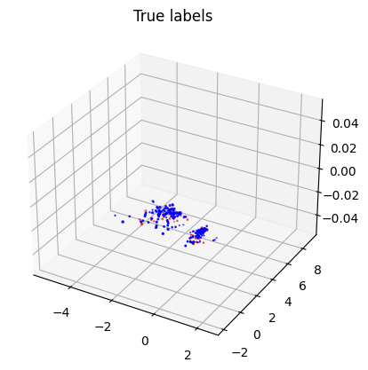

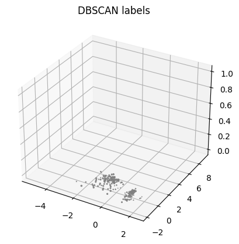

```python
PCAs = [0,1,2]

data = df.drop(['Class'],axis=1)
DB = DBSCAN(eps=0.2, min_samples=100).fit(df)
class0 = np.where(DB.labels_ == 0)
class1 = np.where(DB.labels_ == 1)
outliers = np.where(DB.labels_ == -1)
print(len(outliers[0]))
df_array = np.array(df)
true_class_0 = np.where(df_array[:,-1] == 0)
true_class_1 = np.where(df_array[:,-1] == 1)

sample0 = np.random.choice(len(np.array(true_class_0[0])),400)
sample1 = np.random.choice(len(np.array(true_class_1[0])),100)

samples = []
for i in range(len(sample0)):
    samples.append(sample0[i])
for i in range(len(sample1)):
    samples.append(sample1[i])

class0 = []
class1 = []
classneg1 = []
for i in range(len(samples)):
    if DB.labels_[samples[i]] == 0:
        class0.append(samples[i])
    if DB.labels_[samples[i]] == 1:
        class1.append(samples[i])
    else:
        classneg1.append(samples[i])


fig1 = plt.figure(1)
ax = fig1.add_subplot(projection='3d')
plt.title('True labels')
plt.scatter(df_array[sample0,PCAs[0]],df_array[sample0,PCAs[1]],df_array[sample0,PCAs[2]], color = 'blue')
plt.scatter(df_array[sample1,PCAs[0]],df_array[sample1,PCAs[1]],df_array[sample1,PCAs[2]], color = 'red')
fig1.show

fig2 = plt.figure(2)
ax = fig2.add_subplot(projection='3d')
plt.title('DBSCAN labels')
plt.scatter(df_array[class0,PCAs[0]],df_array[class0,PCAs[1]],df_array[class0,PCAs[2]], color = 'blue')
plt.scatter(df_array[class1,PCAs[0]],df_array[class1,PCAs[1]],df_array[class1,PCAs[2]], color = 'red')
plt.scatter(df_array[classneg1,PCAs[0]],df_array[classneg1,PCAs[1]],df_array[classneg1,PCAs[2]], color = 'grey')
fig2.show
```

### Conclusion

[figure not shown]

Created in Deepnote